# Script8_Armbruster2026_Preparation_for_MapMyCell

Daniel Armbruster

2026-07-24

- In this script we exported the raw count matrix from our annotated zebrafish CA cluster containing Seurat object generated in Script 3 in order to use it as input for the browser-based version of MapMyCells (Allan Institute; RRID:SCR_024672). We used the MapMyCells hierarchical mapping approach to assign cells based on their gene expression profiles to labels of the taxonomy tree of a whole mouse brain dataset published by Yao and colleagues (Yao et. al., 2023; DOI: 10.1038/s41586-023-06812-z). Cell names were modified to include the original cluster annotation to be able to retrieve the corresponding zebrafish cluster identity after mapping. The .csv file generated in this script will be used as input for the Armbruster2026_MapMyCellInputGeneration.ipynb jupyter notebook, where we convert the zebrafish gene symbols to their corresponding mouse homologs before MapMyCells analysis.
- Converted the annotated zebrafish CA Seurat object generated in Script 3 into an AnnData object for downstream analyses in Python.
- For Figures 5B–C, we compared the expression of selected marker genes between zebrafish CA clusters and the corresponding mouse subclasses identified by MapMyCells (Allen Institute; RRID:SCR_024672) using the Whole Mouse Brain dataset published by Yao et al. (2023; DOI: 10.1038/s41586-023-06812-z). As the mouse reference dataset was analyzed in Python as an AnnData object, the zebrafish dataset was converted into the same format to enable comparable visualization of gene expression using Scanpy.
- The session info including the used packages and their versions is provided at the end of this script.

# 1. Load Packages

```r
library(Seurat)
library(tidyverse)
library(ggplot2)
library(SeuratDisk)
library(scCustomize)
library(reticulate)
```

# 2. Load Data

```r
seurat_annotated_all <- readRDS(file = "RDS_files/Script3_Armbruster2026_annotated.rds")
```

# 3. Filter for relevant clusters

- Select the brain specific clusters for comparison with the mouse brain reference.

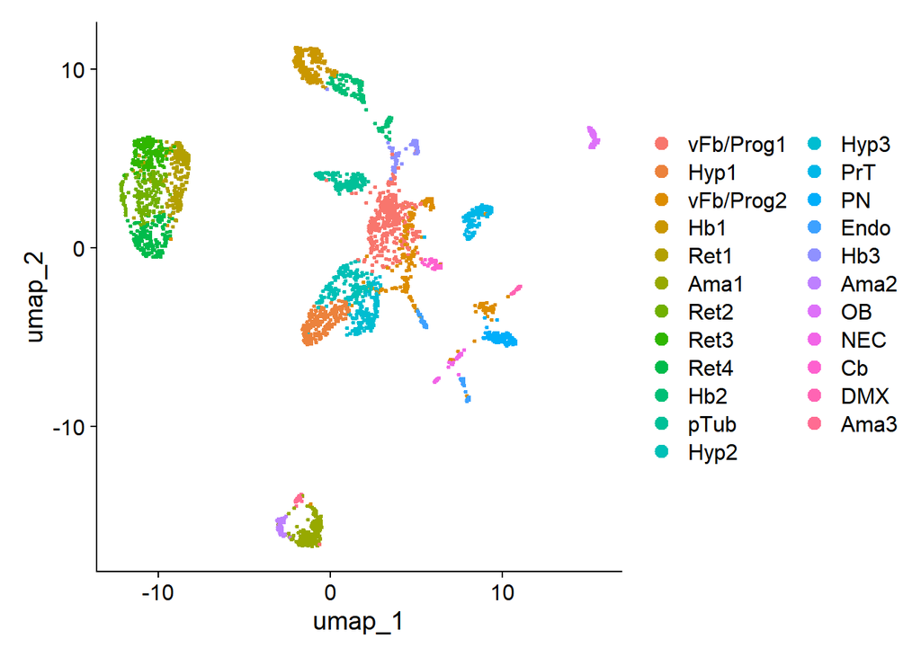

```r
DimPlot(seurat_annotated_all)
```

```r
seurat_annotated_all <- subset(x=seurat_annotated_all, idents = c("vFb/Prog1", "Hyp1", "vFb/Prog2", "Hb1", "Hb2", "pTub", "Hyp2", "Hyp3", "PrT", "Hb3", "OB", "Cb", "DMX"))
```

# 5. Modify cell names to include cluster annotation

```r
# Extract original cluster annotations and cell names
cluster_names <- as.character(seurat_annotated_all$Fig1_annotation)
cell_names <- as.character(seurat_annotated_all$cells)

# Append cluster annotation to each cell name
modified_cell_names <- paste(cell_names, cluster_names, sep="_")

# Extract raw count matrix and replace cell names with modified names
seurat_annotated_all_expression_matrix <- seurat_annotated_all[["RNA"]]$counts
colnames(seurat_annotated_all_expression_matrix) <- modified_cell_names

# Export as csv file
write.csv(seurat_annotated_all_expression_matrix,"MapMyCells/MapMyCells_input_data/modified_expression_matrix_zebrafishnames.csv")
```

# 6. For figure 5

- In figure 5B-C we visualize the expression of selected genes across several zebrafish CA clusters and compare the expression with their expression in mouse subclasses from the Yao et al. 2023 (DOI: 10.1038/s41586-023-06812-z) dataset. Since the mouse data was analysed as anndata object in Python, the zebrafish CA cluster Seurat object was converted into AnnData format. This enabled us to visualize gene expression of similar zebrafish and mouse clusters using Scanpy for more comparable visualization.

## 6.1 Conversion of Seurat to Anndata

```r
# Define python environment to use for AnnData conversion and verify required packages
use_python("C:/Users/Danie/anaconda3/envs/mousebrain/python.exe", required = TRUE)
py_config()
```

```
## python:         C:/Users/Danie/anaconda3/envs/mousebrain/python.exe
## libpython:      C:/Users/Danie/anaconda3/envs/mousebrain/python311.dll
## pythonhome:     C:/Users/Danie/anaconda3/envs/mousebrain
## version:        3.11.11 | packaged by conda-forge | (main, Dec  5 2024, 14:06:23) [MSC v.1942 64 bit (AMD64)]
## Architecture:   64bit
## numpy:          C:/Users/Danie/anaconda3/envs/mousebrain/Lib/site-packages/numpy
## numpy_version:  1.26.4
##
## NOTE: Python version was forced by use_python() function
```

```r
py_run_string("import numpy, h5py; print('numpy', numpy.__version__, 'h5py', h5py.__version__)")
```

```
## numpy 1.26.4 h5py 3.15.1
```

```r
py_run_string("import anndata; print('anndata', anndata.__version__)")
```

```
## anndata 0.12.10
```

```r
# Extract raw and normalized counts from RNA assay
rna_counts <- GetAssayData(seurat_annotated_all, assay = "RNA", layer = "counts")
rna_data   <- GetAssayData(seurat_annotated_all, assay = "RNA", layer = "data")

# Convert Seurat v5 RNA assay into a classic assay format compatible with AnnData conversion
RNA_classic <- CreateAssayObject(counts = rna_counts)
RNA_classic <- SetAssayData(RNA_classic, slot = "data", new.data = rna_data)
RNA_classic@meta.features <- data.frame(row.names = rownames(rna_counts))
seurat_annotated_all[["RNA"]] <- RNA_classic
DefaultAssay(seurat_annotated_all) <- "RNA"

# Export Seurat object as AnnData file with normalized expression as main layer
# and raw counts stored as an additional layer
as.anndata(
  seurat_annotated_all,
  file_path = "D:/scRNAseq/10X/DA136/SeuratAnalysis_2024-09-03/OwnData_anndata_file/",
  file_name = "own_seurat_annotated.h5ad",
  assay = "RNA",
  main_layer = "data",
  other_layers = "counts"
)
```

```
## • Checking Seurat object validity
```

```
## • Extracting Data from RNA assay to transfer to anndata.
## The following columns were removed as they contain identical values for all
## rows:
## ℹ orig.ident, seq_folder, sample, and DF.classifications_0.25_0.22_271
## • Creating anndata object.
## • Writing anndata file:
##   "D:\\scRNAseq\\10X\\DA136\\SeuratAnalysis_2024-09-03\\OwnData_anndata_file/own_seurat_annotated.h5ad"
```

```
## AnnData object with n_obs × n_vars = 1922 × 20017
##     obs: 'nCount_RNA', 'nFeature_RNA', 'nUMI', 'nGene', 'log10GenesPerUMI', 'EGFPratio', 'MTratio', 'cells', 'pANN_0.25_0.22_271', 'S.Score', 'G2M.Score', 'Phase', 'nCount_SCT', 'nFeature_SCT', 'SCT_snn_res.1', 'seurat_clusters', 'Fig1_annotation'
##     var: 'names'
##     obsm: 'X_pca', 'X_umap'
##     layers: 'counts_RNA'
```

```r
rm(list=ls())
gc()
```

```
##            used  (Mb) gc trigger   (Mb)  max used   (Mb)
## Ncells  4176263 223.1    7554731  403.5   7554731  403.5
## Vcells 52061467 397.2  154232246 1176.7 192689547 1470.2
```